# Geographic Selection Mosaic in *Passiflora caerulea*

Facundo X. Palacio

2026-04-01

# 1 Load required packages

```r
library(dplyr) # data handling
library(tidyr) # data handling
library(purrr) # data handling
library(ggplot2) # plots
library(mgcv) # GAMs
library(gratia) # GAMs
library(boot) # bootstrapping
library(numDeriv) # partial derivatives
library(pheatmap) # heatmaps
library(betapart) # assemblage composition
library(gdm) # GDM
library(here) # for path reading

knitr::opts_chunk$set(
  echo = TRUE,
  warning = FALSE,
  message = FALSE,
  fig.width = 7,
  fig.height = 5,
  fig.align = "center"
)
```

# 2 Load and preprocess fruit data

```r
fruit_data <- read.csv(here("data", "Passionflower_full.csv"))

# Compute mean trait values per plant
mean_plant_data <- fruit_data %>%
  group_by(populationID, plantID) %>%
  summarise(
    xDiam   = mean(diam_mm, na.rm = TRUE),
    xNseeds = mean(Nseeds, na.rm = TRUE),
    xSugar  = mean(sugar_brix, na.rm = TRUE),
    .groups = "drop"
  )

# Correlation matrices by population
cors_by_pop <- mean_plant_data %>%
  group_by(populationID) %>%
  nest() %>%
  mutate(
    cor_matrix = map(data, ~ cor(.x[, c("xDiam", "xNseeds", "xSugar")],
                                use = "pairwise.complete.obs"))
  )

# Print results
cors_by_pop$cor_matrix %>% map(~ round(.x, 3))
```

```
## [[1]]
##         xDiam xNseeds xSugar
## xDiam   1.000   0.122  0.270
## xNseeds 0.122   1.000 -0.247
## xSugar  0.270  -0.247  1.000
##
## [[2]]
##          xDiam xNseeds xSugar
## xDiam    1.000   0.425 -0.178
## xNseeds  0.425   1.000 -0.351
## xSugar  -0.178  -0.351  1.000
##
## [[3]]
##         xDiam xNseeds xSugar
## xDiam   1.000   0.085  0.143
## xNseeds 0.085   1.000  0.218
## xSugar  0.143   0.218  1.000
##
## [[4]]
##          xDiam xNseeds xSugar
## xDiam    1.000   0.469 -0.156
## xNseeds  0.469   1.000 -0.372
## xSugar  -0.156  -0.372  1.000
##
## [[5]]
##          xDiam xNseeds xSugar
## xDiam    1.000   0.414 -0.189
## xNseeds  0.414   1.000 -0.152
## xSugar  -0.189  -0.152  1.000
##
## [[6]]
##          xDiam xNseeds xSugar
## xDiam    1.000   0.604 -0.015
## xNseeds  0.604   1.000 -0.338
## xSugar  -0.015  -0.338  1.000
##
## [[7]]
##         xDiam xNseeds xSugar
## xDiam   1.000   0.654  0.148
## xNseeds 0.654   1.000 -0.059
## xSugar  0.148  -0.059  1.000
##
## [[8]]
##         xDiam xNseeds xSugar
## xDiam   1.000   0.794  0.466
## xNseeds 0.794   1.000  0.195
## xSugar  0.466   0.195  1.000
##
## [[9]]
##         xDiam xNseeds xSugar
## xDiam   1.000   0.303     NA
## xNseeds 0.303   1.000     NA
## xSugar     NA      NA     NA
##
## [[10]]
##         xDiam xNseeds xSugar
## xDiam   1.000   0.270  0.395
## xNseeds 0.270   1.000  0.143
## xSugar  0.395   0.143  1.000
```

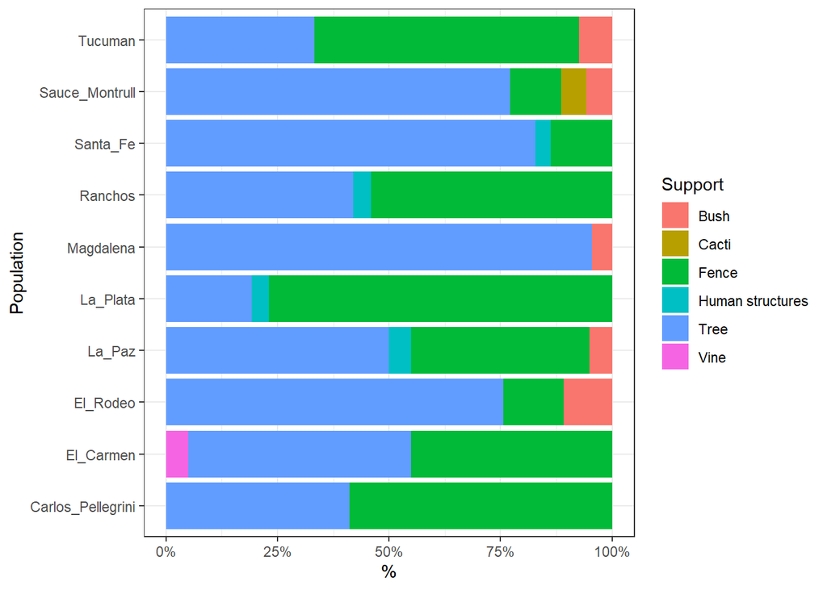

```r
# Load plant-level data
plant_data <- read.csv(here("data", "Passionflower_pops.csv"))

# Group support types into broader categories
plant_data <- plant_data %>%
  mutate(
    support_group = case_when(
      support %in% c("brick_pile", "light_post", "metal_sheet") ~ "Human structures",
      support %in% c("fence", "fence_gate", "living_fence", "wire_fence") ~ "Fence",
      support %in% c("bush", "standing_dead_bush", "unidentified_bush",
                     "Baccharis_sp", "Eryngium_sp", "Lycium_cestroides") ~ "Bush",
      support == "vine" ~ "Vine",
      support == "Opuntia_sp" ~ "Cacti",
      TRUE ~ "Tree"
    )
  )

# Plot support use across populations
ggplot(plant_data, aes(x = populationID, fill = support_group)) +
  geom_bar(position = "fill") +
  coord_flip() +
  scale_y_continuous(labels = scales::percent_format()) +
  theme_bw() +
  labs(x = "Population", y = "%", fill = "Support")
```

# 3 Fit GAM models per population

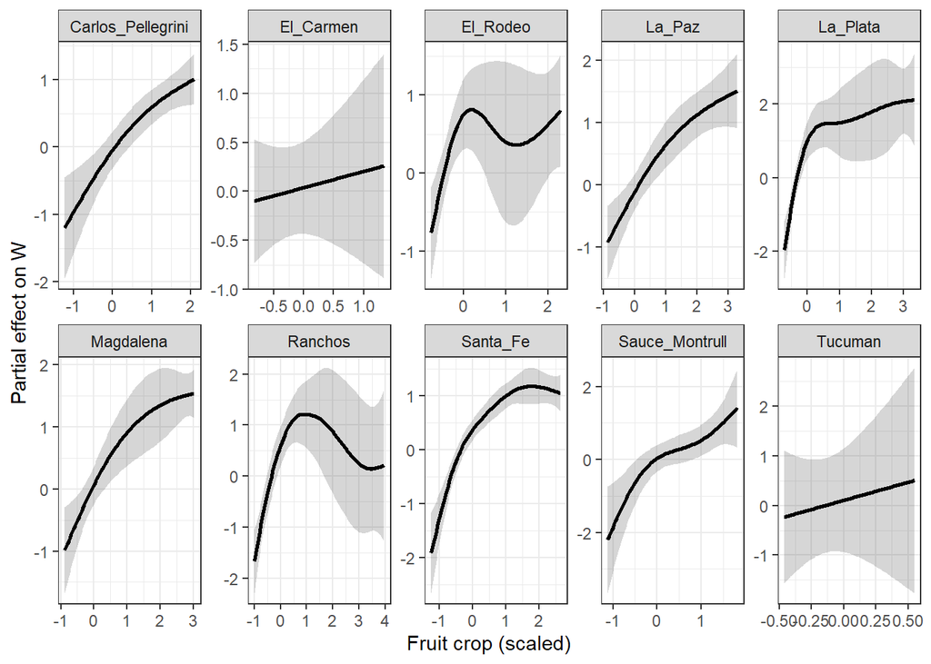

```r
df_models <- plant_data %>%
  group_by(populationID) %>%
  nest() %>%
  mutate(
    data_scaled = map(data, ~ {
      z <- scale(data.frame(
        zcrop  = .x$fruit_crop,
        zdiam  = .x$xDiam,
        zseeds = .x$xNseeds
      )) %>% as.data.frame()

      na.omit(bind_cols(z, W = .x$pecked_fruits))
    }),
    k_val = map_int(data_scaled, ~ round(nrow(.x)/4)),
    gam_fit = map2(data_scaled, k_val, ~
      gam(W ~ s(zcrop, k = .y) +
            s(zdiam, k = .y) +
            s(zseeds, k = .y),
          family = nb(),
          data = .x)
    )
  )

# Plot models
df_smooths <- df_models %>%
  mutate(
    smooths = map(gam_fit, ~ smooth_estimates(.x))
  ) %>%
  select(populationID, smooths) %>%
  unnest(smooths)

df_crop <- df_smooths %>%
  filter(.smooth == "s(zcrop)") %>%
  mutate(
    x = zcrop,
    estimate = .estimate,
    lower = .estimate - 2*.se,
    upper = .estimate + 2*.se
  ) %>%
  select(populationID, x, estimate, lower, upper)

p_crop <- df_crop %>%
  ggplot(aes(x = x, y = estimate)) +
  geom_ribbon(aes(ymin = lower, ymax = upper), alpha = 0.2) +
  geom_line(size = 1) +
  facet_wrap(~ populationID, ncol = 5, scales = "free") +
  labs(x = "Fruit crop (scaled)", y = "Partial effect on W") +
  theme_bw()

p_crop
```

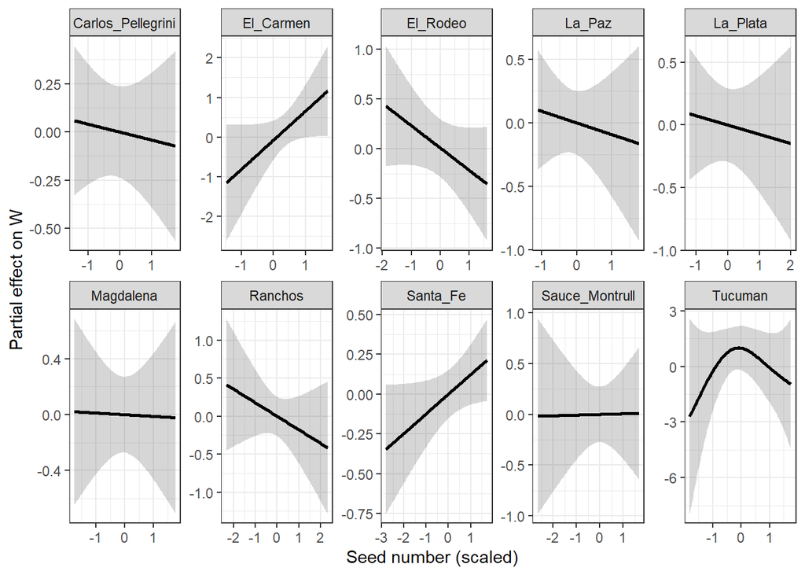

```r
df_seed <- df_smooths %>%
  filter(.smooth == "s(zseeds)") %>%
  mutate(
    x = zseeds,
    estimate = .estimate,
    lower = .estimate - 2*.se,
    upper = .estimate + 2*.se
  ) %>%
  select(populationID, x, estimate, lower, upper)

p_seed <- df_seed %>%
  ggplot(aes(x = x, y = estimate)) +
  geom_ribbon(aes(ymin = lower, ymax = upper), alpha = 0.2) +
  geom_line(size = 1) +
  facet_wrap(~ populationID, ncol = 5, scales = "free") +
  labs(x = "Seed number (scaled)", y = "Partial effect on W") +
  theme_bw()

p_seed
```

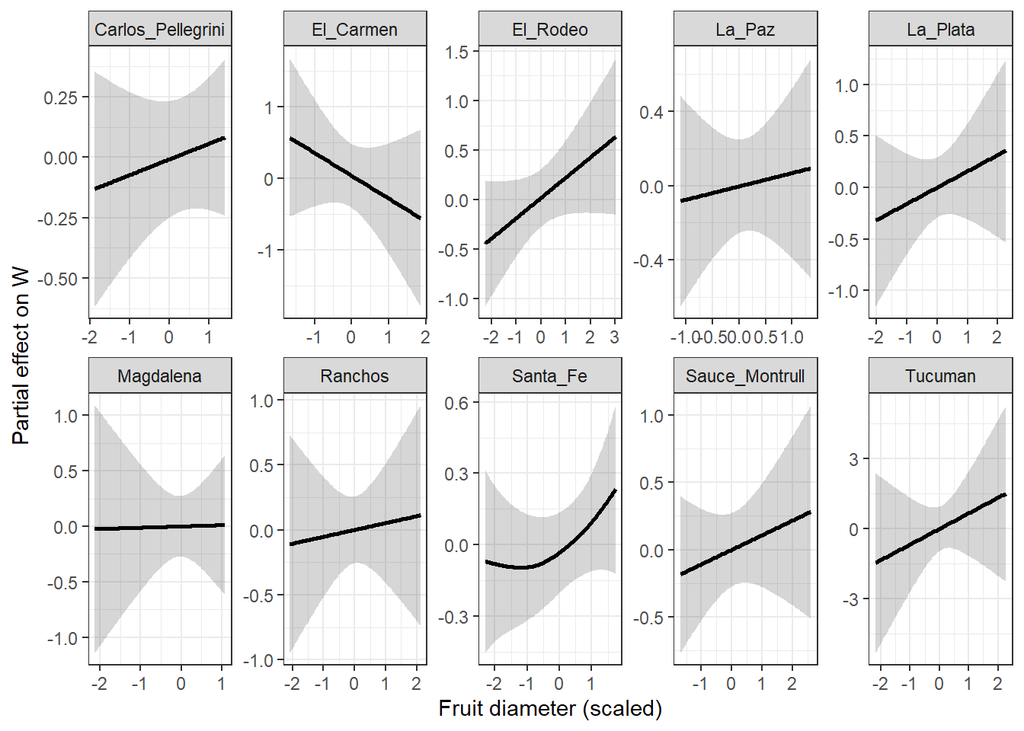

```r
df_diam <- df_smooths %>%
  filter(.smooth == "s(zdiam)") %>%
  mutate(
    x = zdiam,
    estimate = .estimate,
    lower = .estimate - 2*.se,
    upper = .estimate + 2*.se
  ) %>%
  select(populationID, x, estimate, lower, upper)

p_diam <- df_diam %>%
  ggplot(aes(x = x, y = estimate)) +
  geom_ribbon(aes(ymin = lower, ymax = upper), alpha = 0.2) +
  geom_line(size = 1) +
  facet_wrap(~ populationID, ncol = 5, scales = "free") +
  labs(x = "Fruit diameter (scaled)", y = "Partial effect on W") +
  theme_bw()

p_diam
```

# 4 Natural selection analysis

Function to estimate gradients (modified from https://www.rdocumentation.org/packages/gsg/versions/2.0/topics/gam.gradients)

original *boot::boot()* usage is preserved and its statistic(data, original, …) signature so you can keep passing this function to boot() in the same way. The internal bootstrap statistic functions return an NA vector when a replicate fails (instead of stopping), so the bootstrap run completes and SEs are computed ignoring failed replicates (they contribute NA).

*get_theta_positive()* handles both mod$family$theta (already on data scale) and mod$family$getTheta() (often log-scale) robustly.

*simulate_gam_safe()* caps link values (±700) to avoid exp() overflow and checks finiteness.

*posterior* uses mvtnorm::rmvnorm(); make sure mod$Vp exists (mgcv stores it as mod$Vp in many fits). If your model uses another name, adapt that line.

The function prints minimal progress messages but avoids printing many intermediate estimates (so it’s safe for long bootstraps).

```r
gam.gradients <- function(
    mod,
    phenotype,
    covariates = NULL,
    standardized = FALSE,
    se.method = 'boot.para',
    n.boot = 1000,
    parallel = "no",
    ncpus = 1,
    refit.smooth = FALSE
) {
  ## ---- dependencies
  if (!requireNamespace("numDeriv", quietly = TRUE)) stop("numDeriv required")
  if (!requireNamespace("boot", quietly = TRUE)) stop("boot required")
  if (!requireNamespace("mvtnorm", quietly = TRUE)) stop("mvtnorm required")
  if (!inherits(mod, "gam")) stop("Argument 'mod' must be a gam object (mgcv).")
  if (!is.character(phenotype)) stop("Argument 'phenotype' must be character.")
  if (!is.logical(standardized)) stop("Argument 'standardized' must be logical.")
  if (!is.character(se.method)) stop("Argument 'se.method' must be character.")
  if (!is.numeric(n.boot) || n.boot <= 1) stop("Argument 'n.boot' must be > 1.")

  ## ---- helper: safe theta extractor
  get_theta_positive <- function(mod) {
    # Try mod$family$theta (data scale)
    if (!is.null(mod$family$theta) &&
        is.finite(mod$family$theta) &&
        mod$family$theta > 0) {
      return(mod$family$theta)
    }
    # Try accessor getTheta (may return log(theta))
    if (!is.null(mod$family$getTheta)) {
      t <- tryCatch(mod$family$getTheta(),
                    error = function(e) NA_real_,
                    warning = function(w) NA_real_)
      if (is.na(t)) stop("Could not extract theta from model family.")
      if (t <= 0) {
        tp <- exp(t)
        if (!is.finite(tp) || tp <= 0) stop("Extracted log-theta exponentiated is invalid: ", tp)
        return(tp)
      }
      return(t)
    }
    stop("Theta information not found in model family.")
  }

  ## ---- auxiliary: Wbar (mean response with small shifts on phenotype)
  Wbar <- function(x, mod, phenotype, covariates) {
    # Build new data from original model frame (keep columns in correct order)
    vars <- c(phenotype, covariates)
    new.d <- as.data.frame(mod$model[, vars, drop = FALSE])
    # apply the small shift x to the phenotype columns
    for (i in seq_along(x)) {
      new.d[[phenotype[i]]] <- new.d[[phenotype[i]]] + x[i]
    }
    p <- predict(mod, newdata = new.d, type = "response", newdata.guaranteed = TRUE)
    mean(p)
  }

  ## ---- gradients calculator (returns beta vector and gamma matrix)
  gradients_calc <- function(m, phenotype, covariates, standardized) {
    nTraits <- length(phenotype)
    fd <- numDeriv::grad(func = Wbar, x = rep(0, nTraits), mod = m,
                         phenotype = phenotype, covariates = covariates)
    sd2 <- numDeriv::hessian(func = Wbar, x = rep(0, nTraits), mod = m,
                             phenotype = phenotype, covariates = covariates)
    denom <- Wbar(x = rep(0, nTraits), mod = m, phenotype = phenotype, covariates = covariates)
    beta <- fd / denom
    gamma <- sd2 / denom
    if (standardized) {
      sds <- apply(as.matrix(m$model[, phenotype, drop = FALSE]), 2, sd)
      beta <- beta * sds
      gamma <- gamma * outer(sds, sds)
    }
    list(beta = beta, gamma = gamma)
  }

  ## ---- safe simulation for parametric bootstrap
  simulate_gam_safe <- function(mod, data) {
    # predict on link
    sim_lin <- tryCatch(predict(mod, newdata = data, type = "link"),
                        error = function(e) stop("predict() failed in simulate_gam_safe: ", conditionMessage(e)))
    if (anyNA(sim_lin) || any(!is.finite(sim_lin))) {
      stop("Non-finite linear predictor in simulation.")
    }
    # cap links to avoid exp overflow
    max_link <- 700
    sim_lin[sim_lin > max_link] <- max_link
    sim_lin[sim_lin < -max_link] <- -max_link
    mu <- exp(sim_lin)

    fam_name <- if (!is.null(mod$family$family)) mod$family$family else NA
    if (!is.na(fam_name) && grepl("Negative Binomial", fam_name, ignore.case = TRUE)) {
      theta_pos <- get_theta_positive(mod)
      if (!is.finite(theta_pos) || theta_pos <= 0) stop("Invalid positive theta extracted: ", theta_pos)
      s <- rnbinom(n = length(mu), size = theta_pos, mu = mu)
      if (anyNA(s)) stop("rnbinom produced NA in simulate_gam_safe.")
      return(s)
    } else if (!is.na(fam_name) && grepl("Poisson", fam_name, ignore.case = TRUE)) {
      return(rpois(n = length(mu), lambda = mu))
    } else if (!is.na(fam_name) && grepl("Binomial", fam_name, ignore.case = TRUE)) {
      p <- 1 / (1 + exp(-sim_lin))
      return(rbinom(n = length(p), size = 1, prob = p))
    } else if (!is.na(fam_name) && grepl("gaussian", fam_name, ignore.case = TRUE)) {
      sigma <- if (!is.null(mod$sig2)) sqrt(mod$sig2) else sd(mod$model[[1]] - fitted(mod))
      return(rnorm(n = length(mu), mean = sim_lin, sd = sigma))
    } else {
      stop("Unsupported family in simulate_gam_safe: ", fam_name)
    }
  }

  ## ---- bootstrap statistic: case bootstrap (same shape as original)
  boot_gradients_case <- function(data, original, mod, phenotype, covariates) {
    d <- as.data.frame(data)[original, , drop = FALSE]
    # refit gam safely
    refit_try <- tryCatch({
      if (refit.smooth) {
        gam(as.formula(mod$formula), data = d, family = mod$family, start = mod$coefficients)
      } else {
        gam(as.formula(mod$formula), data = d, family = mod$family, start = mod$coefficients, sp = mod$sp)
      }
    }, error = function(e) NULL)
    if (is.null(refit_try)) {
      # return NA vector of expected length
      nTraits <- length(phenotype)
      return(rep(NA_real_, 2 * nTraits + (nTraits^2 - nTraits) / 2))
    }
    g <- gradients_calc(refit_try, phenotype, covariates, standardized)
    c(g$beta, diag(g$gamma), g$gamma[upper.tri(g$gamma)])
  }

  ## ---- bootstrap statistic: parametric bootstrap (used with boot())
  boot_gradients_para <- function(data, original, mod, phenotype, covariates) {
    # 'data' here is mod$model (entire dataset)
    d <- as.data.frame(data)
    response_name <- attr(attr(mod$terms, "factors"), "dimnames")[[1]][1]
    # simulate response; catch simulation errors and return NA vector
    sim_resp <- tryCatch(simulate_gam_safe(mod, d),
                         error = function(e) {
                           warning("simulate_gam_safe failed: ", conditionMessage(e))
                           return(rep(NA_real_, nrow(d)))
                         })
    d[[response_name]] <- sim_resp
```

```r
    # get positive theta if needed for NB
    fam_name <- if (!is.null(mod$family$family)) mod$family$family else NA
    theta_pos <- NULL
    if (!is.na(fam_name) && grepl("Negative Binomial", fam_name, ignore.case = TRUE)) {
      theta_pos <- tryCatch(get_theta_positive(mod), error = function(e) NA_real_)
      if (!is.finite(theta_pos) || theta_pos <= 0) {
        warning("Invalid theta extracted inside parametric bootstrap; returning NA replicate.")
        nTraits <- length(phenotype)
        return(rep(NA_real_, 2 * nTraits + (nTraits^2 - nTraits) / 2))
      }
    }

    # refit safely (wrap in tryCatch)
    mod_prime <- tryCatch({
      if (!is.null(theta_pos)) {
        if (refit.smooth) {
          gam(as.formula(mod$formula), data = d, family = negbin(theta_pos), start = mod$coefficients)
        } else {
          gam(as.formula(mod$formula), data = d, family = negbin(theta_pos), start = mod$coefficients, sp = mod$sp)
        }
      } else {
        if (refit.smooth) {
          gam(as.formula(mod$formula), data = d, family = mod$family, start = mod$coefficients)
        } else {
          gam(as.formula(mod$formula), data = d, family = mod$family, start = mod$coefficients, sp = mod$sp)
        }
      }
    }, error = function(e) {
      warning("Refit failed inside parametric bootstrap: ", conditionMessage(e))
      NULL
    })

    if (is.null(mod_prime)) {
      nTraits <- length(phenotype)
      return(rep(NA_real_, 2 * nTraits + (nTraits^2 - nTraits) / 2))
    }

    g <- gradients_calc(mod_prime, phenotype, covariates, standardized)
    c(g$beta, diag(g$gamma), g$gamma[upper.tri(g$gamma)])
  }

  ## ---- permutation statistic (permute response then refit)
  permute_W_refit <- function(data, original, mod, phenotype, covariates) {
    # construct a fresh data frame from original mod$model
    response_name <- attr(attr(mod$terms, "factors"), "dimnames")[[1]][1]
    vars <- c(response_name, phenotype, covariates)
    d <- as.data.frame(mod$model[, vars, drop = FALSE])
    # permute response across rows
    d[[response_name]] <- sample(d[[response_name]], size = nrow(d), replace = FALSE)
    mod_prime <- tryCatch({
      gam(as.formula(mod$formula), data = d, family = mod$family, start = mod$coefficients)
    }, error = function(e) NULL)
    if (is.null(mod_prime)) {
      nTraits <- length(phenotype)
      # NOTE: original permute returned also var(p). We'll return the NA vector plus NA var
      return(c(rep(NA_real_, 2 * nTraits + (nTraits^2 - nTraits) / 2), NA_real_))
    }
    p <- predict(mod_prime, type = "response")
    g <- gradients_calc(mod_prime, phenotype, covariates, standardized)
    c(c(g$beta, diag(g$gamma), g$gamma[upper.tri(g$gamma)]), var(p))
  }

  ## ---- posterior simulation (MVN on coefficients)
  posterior_sim_gradients <- function(m, nboot, phenotype, covariates, standardized) {
    mu <- m$coefficients
    Vp <- m$Vp
    if (is.null(Vp)) stop("Model lacks Vp matrix required for posterior simulation.")
    coef.boot <- mvtnorm::rmvnorm(n = nboot, mean = mu, sigma = Vp)
    nTraits <- length(phenotype)
    out <- matrix(NA_real_, nrow = nboot, ncol = 2 * nTraits + (nTraits^2 - nTraits) / 2)
    for (b in seq_len(nboot)) {
      mprime <- m
      mprime$coefficients <- coef.boot[b, ]
      g <- gradients_calc(mprime, phenotype, covariates, standardized)
      out[b, ] <- c(g$beta, diag(g$gamma), g$gamma[upper.tri(g$gamma)])
    }
    out
  }

  ## ---- checks and initial estimates
  termLabels <- attr(terms(mod), "term.labels")
  if (!all(phenotype %in% termLabels)) stop("Some selected phenotypes not included in model terms.")
  nTraits <- length(phenotype)

  # compute point estimates
  g0 <- gradients_calc(mod, phenotype, covariates, standardized)
  est_vec <- c(g0$beta, diag(g0$gamma), g0$gamma[upper.tri(g0$gamma)])

  # prepare result container
  ests <- data.frame(Estimate = est_vec, row.names = NULL)
  rownames(ests)[1:nTraits] <- paste0("B-", phenotype)
  rownames(ests)[(nTraits + 1):(2 * nTraits)] <- paste0("G-", phenotype)
  if (nTraits > 1) {
    cor.names <- function(x, y) paste0("G-", x, "-", y)
    upper_names <- outer(phenotype, phenotype, cor.names)[upper.tri(outer(phenotype, phenotype, cor.names))]
    rownames(ests)[(2 * nTraits + 1):(2 * nTraits + length(upper_names))] <- upper_names
  }

  ## ---- compute SE / P-values depending on method
  boot_res <- NULL
  if (se.method %in% c("posterior", "boot.case", "boot.para")) {
    cat("Calculating bootstrap/posterior standard errors...\n"); flush.console()

    if (se.method == "posterior") {
      boot_res <- posterior_sim_gradients(mod, n.boot, phenotype, covariates, standardized)
      cat("done.\n")
    } else if (se.method == "boot.case") {
      rep1 <- min(100, n.boot)
      # run bootstrap in two stages to give progress estimate (as original)
      b1 <- boot::boot(data = mod$model, statistic = boot_gradients_case, R = rep1,
                       parallel = parallel, ncpus = ncpus, mod = mod,
                       phenotype = phenotype, covariates = covariates)
      if (n.boot <= rep1) {
        boot_res <- b1$t
      } else {
        b2 <- boot::boot(data = mod$model, statistic = boot_gradients_case, R = n.boot - rep1,
                         parallel = parallel, ncpus = ncpus, mod = mod,
                         phenotype = phenotype, covariates = covariates)
        boot_res <- rbind(b1$t, b2$t)
      }
      cat("done.\n")
    } else if (se.method == "boot.para") {
      rep1 <- min(100, n.boot)
      b1 <- boot::boot(data = mod$model, statistic = boot_gradients_para, R = rep1,
                       parallel = parallel, ncpus = ncpus, mod = mod,
                       phenotype = phenotype, covariates = covariates)
      if (n.boot <= rep1) {
        boot_res <- b1$t
      } else {
        b2 <- boot::boot(data = mod$model, statistic = boot_gradients_para, R = n.boot - rep1,
                         parallel = parallel, ncpus = ncpus, mod = mod,
                         phenotype = phenotype, covariates = covariates)
        boot_res <- rbind(b1$t, b2$t)
      }
      cat("done.\n")
    }
```

```r
    # compute SEs and p-values from bootstrap/posterior draws
    ests$SE <- apply(as.data.frame(boot_res), 2, sd, na.rm = TRUE)
    ests$`P-value` <- apply(as.data.frame(boot_res), 2, function(x) {
      x <- x[is.finite(x)]
      if (length(x) == 0) return(NA_real_)
      2 * min(sum(x > 0), sum(x < 0)) / length(x)
    })
  } else if (se.method == "permute") {
    cat("Calculating permutation P-values...\n"); flush.console()
    rep1 <- min(100, n.boot)
    p1 <- boot::boot(data = mod$model, statistic = permute_W_refit, R = rep1,
                     parallel = parallel, ncpus = ncpus, mod = mod,
                     phenotype = phenotype, covariates = covariates)
    if (n.boot <= rep1) {
      perm_res <- p1$t
    } else {
      p2 <- boot::boot(data = mod$model, statistic = permute_W_refit, R = n.boot - rep1,
                       parallel = parallel, ncpus = ncpus, mod = mod,
                       phenotype = phenotype, covariates = covariates)
      perm_res <- rbind(p1$t, p2$t)
    }
    # perm_res includes an extra column for var(p), so drop that when computing P-values
    n.grads <- ncol(perm_res) - 1
    diffs <- perm_res[, 1:n.grads, drop = FALSE] - matrix(est_vec, nrow = nrow(perm_res), ncol = length(est_vec), byrow = TRUE)
    ests$SE <- NA
    ests$`P-value` <- apply(diffs, 2, function(x) {
      x <- x[is.finite(x)]
      if (length(x) == 0) return(NA_real_)
      2 * min(sum(x > 0), sum(x < 0)) / length(x)
    })
  } else if (se.method == "n") {
    ests$SE <- rep(NA_real_, length(est_vec))
    ests$`P-value` <- rep(NA_real_, length(est_vec))
  } else {
    warning("se.method not recognized; returning estimates only.")
    ests$SE <- rep(NA_real_, length(est_vec))
    ests$`P-value` <- rep(NA_real_, length(est_vec))
  }

  # final formatting: name rows
  rownames(ests) <- rownames(ests)

  # return; include raw bootstrap draws when relevant
  res <- ests
  if (se.method %in% c("posterior", "boot.case", "boot.para")) res <- list(ests = ests, boot = boot_res)
  if (se.method == "permute") res <- list(ests = ests, perm = perm_res)
  res
}
```

# 5 Compute selection gradients

```r
set.seed(1)
popsID <- unique(plant_data$populationID)
npops <- length(popsID)
estimates_grads <- list()
for(i in 1:npops){
pop <- subset(plant_data, populationID == popsID[i])

# Standardized traits
z <- scale(data.frame(zcrop = pop$fruit_crop, zdiam = pop$xDiam,
                 zseeds = pop$xNseeds))

# Fitness (number of pecked fruits)
W <- pop$pecked_fruits

# Fitness function
trait_fitness <- na.omit(data.frame(z, W))
k <- round((1/4)*nrow(trait_fitness), 0) # k = 1/4 of sample size
ff <- gam(W ~ s(zcrop) + s(zdiam) + s(zseeds, k = k),
          family = nb(), data = trait_fitness)

# Selection gradients
sel.grads <- gam.gradients(mod = ff,
                       phenotype = c("zcrop", "zdiam",
                                     "zseeds"),
              covariates = NULL, standardized = TRUE,
              se.method = "boot.para", n.boot = 1000,
              parallel = "no", ncpus = 1, refit.smooth = FALSE)

estimates_grads[[i]] <- sel.grads$ests
}

# Export data
# for(i in 1:length(popsID)){
#  write.csv(estimates_grads[[i]], paste(popsID[i],
# "csv", sep = "."), row.names = T)
# }
```

# 6 Cosine similarity in linear selection gradients between populations

function *compare_linear_gradients*: - pop_beta: data.frame o matrix. If data.frame must contain population id column (pop_col) OR you can pass a matrix/data.frame with rownames = population ids and pop_col = NULL. - pop_col: name of the population ID column (string). If NULL, rownames(pop_beta) used. - beta_cols: character vector of beta column names. If NULL, all numeric columns except pop_col are used.

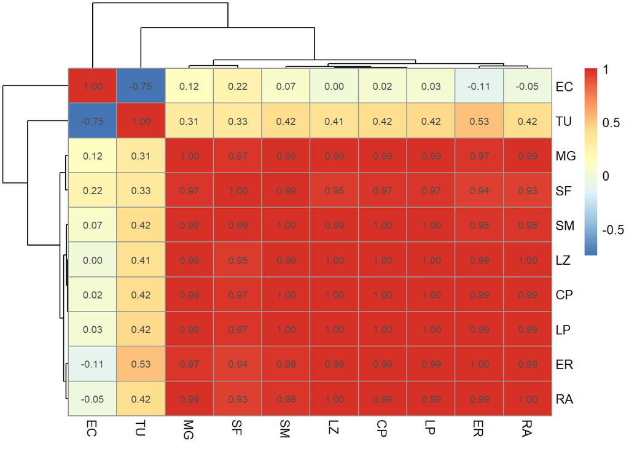

```r
# Linear selection
betas <- read.table(here("data", "betas.txt"), head = T)
rownames(betas) <- betas$populationID
compare_linear_gradients <- function(pop_beta, pop_col = "populationID", beta_cols = NULL) {

  # prepare input: data.frame
  if(is.null(pop_col)) {
    # expect rownames to have pop ids
    if(is.null(rownames(pop_beta))) stop("pop_col is NULL, but pop_beta has no rownames with population IDs.")
    df <- as.data.frame(pop_beta)
    df[[ "populationID_internal_temp_col123" ]] <- rownames(pop_beta)
    pop_col_use <- "populationID_internal_temp_col123"
  } else {
    df <- as.data.frame(pop_beta)
    if(!pop_col %in% names(df)) stop("pop_col not found in pop_beta.")
    pop_col_use <- pop_col
  }

  # choose beta columns
  if(is.null(beta_cols)) {
    # all numeric columns except population id
    beta_cols_use <- names(df)[sapply(df, is.numeric) & names(df) != pop_col_use]
    if(length(beta_cols_use) == 0) stop("No numeric beta columns found. Provide beta_cols.")
  } else {
    if(!all(beta_cols %in% names(df))) stop("Some beta_cols not found in data.")
    beta_cols_use <- beta_cols
  }

  # build matrix of betas: one row per population, columns = betas
  betamat <- df %>%
    select(all_of(c(pop_col_use, beta_cols_use))) %>%
    group_by(across(all_of(pop_col_use))) %>%
    # if duplicates per population, average (safe default)
    summarise(across(all_of(beta_cols_use), ~ mean(.x, na.rm = TRUE)), .groups = "drop") %>%
    arrange(!!sym(pop_col_use))

  pop_ids <- betamat[[pop_col_use]]
  B <- as.matrix(betamat %>% select(all_of(beta_cols_use)))
  rownames(B) <- pop_ids

  # compute norms and unit vectors
  norms <- sqrt(rowSums(B^2, na.rm = TRUE))
  zero_norms <- which(is.na(norms) | norms == 0)
  if(length(zero_norms) > 0) {
    warning("The following populations have zero or NA norm (all-zero or NA betas): ",
            paste(rownames(B)[zero_norms], collapse = ", "),
            ". Their similarities will be NA.")
  }
  # normalize rows
  U <- B/norms
  # ensure numeric NA propagation handled: if norm NA or zero, row becomes NA
  U[is.infinite(U)] <- NA_real_

  # pairwise cosine similarities (dot products of unit vectors)
  n <- nrow(U)
  cos_mat <- matrix(NA_real_, nrow = n, ncol = n, dimnames = list(pop_ids, pop_ids))
  angle_mat <- matrix(NA_real_, nrow = n, ncol = n, dimnames = list(pop_ids, pop_ids))

  for(i in seq_len(n)) {
    for(j in seq_len(n)) {
      ui <- U[i, ]
      vj <- U[j, ]
      if(any(is.na(ui)) || any(is.na(vj))) {
        cos_val <- NA_real_
      } else {
        # dot product
        cos_val <- sum(ui*vj)
        # numerical safety
        cos_val <- min(1, max(-1, cos_val))
      }
      cos_mat[i,j] <- cos_val
      angle_mat[i,j] <- ifelse(is.na(cos_val), NA_real_, acos(cos_val) * 180 / pi)
    }
  }

  # long table
  long_df <- expand.grid(pop1 = pop_ids, pop2 = pop_ids, stringsAsFactors = FALSE) %>%
    arrange(pop1, pop2) %>%
    mutate(
      cosine = as.vector(cos_mat),
      angle_deg = as.vector(angle_mat)
    )

  return(list(
    beta_matrix = B,
    unit_matrix = U,
    cosine_matrix = cos_mat,
    angle_matrix_deg = angle_mat,
    long = long_df
  ))
}

sim_matrix <- compare_linear_gradients(betas,
                                pop_col = "populationID",
                                beta_cols = colnames(betas[,-1]))

# Similarity matrix
sim_mat <- sim_matrix$cosine_matrix
# write.csv(sim_mat, "beta_sim.csv")

library(pheatmap)
pheatmap(
  sim_mat,
  cluster_rows = TRUE,
  cluster_cols = TRUE,
  display_numbers = TRUE,
  number_format = "%.2f"
)
```

# 7 Krzanowski’s subspace similarity in nonlinear selection gradients between populations

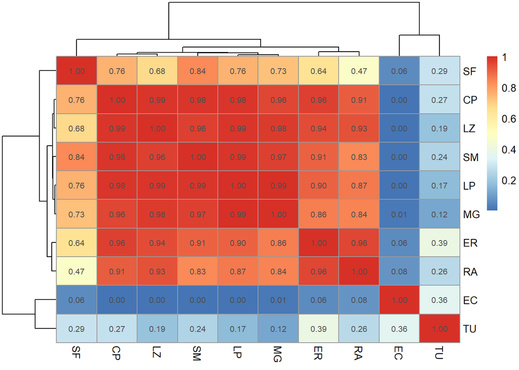

```r
krzanowski_similarity <- function(G1, G2, k = NULL) {
  n <- ncol(G1) # dimension

  if (is.null(k)) {
    k <- floor(n/2)   # enforce Krzanowski's condition
  }

  if (k < 1) stop("k must be at least 1")
  if (k > n) stop("k exceeds matrix dimension")

  # eigendecomposition
  eig1 <- eigen(G1)
  eig2 <- eigen(G2)

  # top k eigenvectors (columns)
  A <- eig1$vectors[, 1:k, drop = FALSE]
  B <- eig2$vectors[, 1:k, drop = FALSE]

  # Krzanowski's S matrix
  S <- t(A) %*% B %*% t(B) %*% A

  # similarity score: sum eigenvalues of S
  sim <- sum(eigen(S, only.values = TRUE)$values)

  return(sim)
}

compare_nonlin_gradients <- function(G_list, k = NULL) {

  n <- ncol(G_list[[1]])
  if (is.null(k)) k <- floor(n/2)

  pops <- names(G_list)
  np   <- length(G_list)


  sim_mat <- matrix(NA, np, np, dimnames = list(pops, pops))

  for (i in 1:np) {
    for (j in 1:np) {
      sim_mat[i, j] <- krzanowski_similarity(G_list[[i]], G_list[[j]], k)/k # divide by k to ensure that values range between 0 and 1
    }
  }

  return(sim_mat)
}

# List of nonlinear gradient matrices
G_files <- list.files(path = here("data", "gamma_matrices"),
                      pattern = "\\.csv$", full.names = TRUE)

# Extract clean names (without .csv)
G_names <- tools::file_path_sans_ext(basename(G_files))

# Read & convert to matrices
G_mats_list <- lapply(G_files, read.csv)

# Assign names
names(G_mats_list) <- G_names

# Compute Krzanowski similarity
similarity_matrix <- compare_nonlin_gradients(G_mats_list)
# write.csv(similarity_matrix, "gamma_sim.csv")

pheatmap(
  similarity_matrix,
  cluster_rows = TRUE,
  cluster_cols = TRUE,
  display_numbers = TRUE,
  number_format = "%.2f"
)
```

# 8 Beta functional diversity

```r
birdtraits <- read.table(here("data", "frugivore_traits.txt"), head = T)
traits <- birdtraits[, c("handling", "BodyMass.Value")]
traits$handling_f <- ifelse(traits$handling == "gulper", 1, 0)
rownames(traits) <- birdtraits$code
trait_mat <- traits[, c("BodyMass.Value", "handling_f")]

comm_matrix <- read.csv(here("data", "comm_passionflower.csv"))
comm <- comm_matrix[,-1]
comm <- 1*(comm>0) # presence-absence matrix
rownames(comm) <- comm_matrix$X

beta_FD <- functional.beta.pair(comm, trait_mat,
                                 index.family = "jaccard")
# write.csv(as.matrix(beta_FD$funct.beta.jac), "beta_FD.csv")

# Difference in the proportion of gulpers
birdtraits <- read.table(here("data", "frugivore_traits.txt"),  head = TRUE)
traits <- birdtraits[, c("handling", "BodyMass.Value")]
# convert handling to numeric binary trait
traits$handling_f <- ifelse(traits$handling == "gulper", 1, 0)
rownames(traits) <- birdtraits$code
trait_mat <- traits[, c("BodyMass.Value", "handling_f")]

comm_matrix <- read.csv(here("data", "comm_passionflower.csv"))
comm <- comm_matrix[,-1]
rownames(comm) <- comm_matrix$X

# Compute proportion of gulpers per assemblage
# align species
species_ok <- intersect(colnames(comm), rownames(traits))
comm <- comm[, species_ok]
trait_mat <- trait_mat[species_ok, ]
# logical vector of gulpers
is_gulper <- trait_mat$handling_f == 1
# proportion of gulpers per site
prop_gulpers <- rowSums(comm[, is_gulper, drop = FALSE]) /
  rowSums(comm, na.rm = TRUE)
# distance = absolute difference in proportions
dist_prop <- as.matrix(dist(prop_gulpers, method = "euclidean"))

# Align species between community matrix and traits
species_ok <- intersect(colnames(comm), rownames(trait_mat))
comm <- comm[, species_ok]
trait_mat <- trait_mat[species_ok, ]

# Binary gulper trait (0/1)
gulper_trait <- trait_mat$handling_f

# Abundance-weighted mean gulper score per assemblage
mean_gulper_abund <- rowSums(comm*gulper_trait, na.rm = TRUE) /
  rowSums(comm, na.rm = TRUE)

# Pairwise distance: absolute difference (Euclidean in 1D)
dist_gulper_abund <- as.matrix(
  dist(mean_gulper_abund, method = "euclidean")
)
# write.csv(dist_gulper_abund, "beta_FD_propGulpers_abund.csv")

# Mean body mass per population
# Community matrix with abundances
comm_matrix <- read.csv(here("data", "comm_passionflower.csv"))
comm <- comm_matrix[, -1]             # remove column name if this exists
rownames(comm) <- comm_matrix$X       # site names

# Filter and reorder to match
comm <- comm[, colnames(comm) %in% rownames(traits)]
traits <- traits[colnames(comm), ]

# Mean body mass
mean_mass <- apply(comm, 1, function(x) {
  species_present <- names(x)[x > 0]          # present species
  trait_values <- traits[species_present, "BodyMass.Value"]
  mean(trait_values, na.rm = TRUE)
})

# Matrix of absolute differences between assemblages
n_sites <- nrow(comm)
site_names <- rownames(comm)

bodymass_diff <- matrix(
  NA, n_sites, n_sites,
  dimnames = list(site_names, site_names)
)

for(i in 1:n_sites){
  for(j in 1:n_sites){
    bodymass_diff[i, j] <-
      abs(mean_mass[i] - mean_mass[j])
  }
}

# Convert to data frame for GDM
bodymass_diff_df <- as.data.frame(bodymass_diff)
# write.csv(bodymass_diff_df, "beta_FD_meanBodyMass.csv")
```

# 9 Generalized dissimilarity modeling

## 9.1 Prepare response and covariates

```r
##### Linear gradient matrix (response 1)
lin_grad <- read.csv(here("data", "beta_sim.csv"))
lin_grad[, -1] <- 1 - abs(lin_grad[, -1]) # Absolute values and dissimilarity
lin_grad$populationID <- 1:nrow(lin_grad)
colnames(lin_grad) <- c("site", lin_grad$populationID)
dim(lin_grad) # first column = site
```

```
## [1] 10 11
```

```r
##### Nonlinear gradient matrix (response 2)
nonlin_grad <- read.csv(here("data", "gamma_sim.csv"))
nonlin_grad[, -1] <- 1 - nonlin_grad[, -1]
nonlin_grad$populationID <- 1:nrow(nonlin_grad)
colnames(nonlin_grad) <- c("site", nonlin_grad$populationID)
dim(nonlin_grad) # first column = site
```

```
## [1] 10 11
```

```r
##### Beta-diversity (Bray-Curtis) (predictor 1)
beta_div <- read.csv(here("data", "comp_div.csv"))[,-1]
rownames(beta_div) <- colnames(beta_div)
dim(beta_div)
```

```
## [1] 10 10
```

```r
# Order rows/columns alphabetically
ord <- order(rownames(beta_div))
beta_div <- beta_div[ord, ord]

# Create numeric site IDs
sites_char <- rownames(beta_div)
sites_num  <- 1:length(sites_char)

# Create numeric-labeled distance matrix for GDM
beta_div_numeric <- beta_div
rownames(beta_div_numeric) <- sites_num
colnames(beta_div_numeric) <- sites_num

# Add "site" column (REQUIRED)
beta_div_numeric <- data.frame(site = sites_num,
                               beta_div_numeric)

#### Functional diversity (proportion of gulpers) (predictor 2)
FD_hand <- read.csv(here("data", "beta_FD_propGulpers.csv"))[,-1]
rownames(FD_hand) <- colnames(FD_hand)
dim(FD_hand)
```

```
## [1] 10 10
```

```r
# Order rows/columns alphabetically
ord <- order(rownames(FD_hand))
FD_hand <- FD_hand[ord, ord]

# Create numeric site IDs
sites_char <- rownames(FD_hand)
sites_num  <- 1:length(FD_hand)

# Create numeric-labeled distance matrix for GDM
FD_hand_numeric <- FD_hand
rownames(FD_hand_numeric) <- sites_num
colnames(FD_hand_numeric) <- sites_num

# Add "site" column (REQUIRED)
FD_hand_numeric <- data.frame(site = sites_num, FD_hand_numeric)

#### Functional diversity (mean body mass) (predictor 3)
FD_BM <- read.csv(here("data", "beta_FD_meanBodyMass.csv"))[,-1]
rownames(FD_BM) <- colnames(FD_BM)

# Order rows/columns alphabetically
ord <- order(rownames(FD_BM))
FD_BM <- FD_BM[ord, ord]

# Create numeric site IDs
sites_char <- rownames(FD_BM)
sites_num  <- 1:length(FD_BM)

# Create numeric-labeled distance matrix for GDM
FD_BM_numeric <- FD_BM
rownames(FD_BM_numeric) <- sites_num
colnames(FD_BM_numeric) <- sites_num

# Add "site" column (REQUIRED)
FD_BM_numeric <- data.frame(site = sites_num, FD_BM_numeric)
dim(FD_BM_numeric)
```

```
## [1] 10 11
```

```r
##### Population density (predictor 4)
populationID <- c("Carlos_Pellegrini", "El_Carmen", "El_Rodeo",
                  "La_Plata", "La_Paz", "Magdalena", "Ranchos",
                  "Tucuman", "Santa_Fe","Sauce_Montrull")
pop_density <- c(760, 134, 910, 4115, 239,
                 0, 874, 5445, 1507, 695)
pop_df <- data.frame(populationID, pop_density)
log_pop <- log(pop_df$pop_density + 1)

# pairwise absolute log-differences
pop_dist <- as.data.frame(
  as.matrix(dist(log_pop, method = "euclidean"))
)
rownames(pop_dist) <- populationID
colnames(pop_dist) <- populationID
pop_dist <- data.frame(populationID, pop_dist)
pop_dist$populationID <- 1:nrow(pop_dist)
colnames(pop_dist) <- c("site", pop_dist$populationID)
dim(pop_dist) # first column = site
```

```
## [1] 10 11
```

```r
##### Geographic coordinates (predictor 5)
plant_data <- read.csv(here("data", "Passionflower_pops.csv"))

coords <- plant_data %>%
  group_by(populationID) %>%
  summarise(
    Long = mean(as.numeric(longitude), na.rm = TRUE),
    Lat  = mean(as.numeric(latitude), na.rm = TRUE)
  )
coords$populationID <- c("CP", "EC", "ER", "LZ", "LP", "MG", "RA",
                         "SF", "SM", "TU")
coords[10, 2] <- -65.26979233 # Longitude Tucuman
coords[10, 3] <- -26.80470395 # Latitude Tucuman
coords[c(4,5), ] <- coords[c(5,4), ] # switch LZ and LP

predData <- data.frame(
  site = sites_num,
  Long = coords$Long,
  Lat  = coords$Lat
)

# Coordinate projection
library(sf)

# Convert to sf
pts <- st_as_sf(predData, coords = c("Long", "Lat"), crs = 4326)

# Project to Argentina TM (EPSG:5347)
pts_proj <- st_transform(pts, 5347)

# Extract projected coordinates back to a data frame
coords <- st_coordinates(pts_proj)

predData_proj <- data.frame(
  site = predData$site,
  Long = coords[,1],
  Lat  = coords[,2]
)
geo_dist <- as.matrix(dist(coords))
rownames(geo_dist) <- populationID
colnames(geo_dist) <- populationID
geo_dist <- data.frame(populationID, geo_dist)
geo_dist$populationID <- 1:nrow(geo_dist)
colnames(geo_dist) <- c("site", geo_dist$populationID)
dim(geo_dist) # first column = site
```

```
## [1] 10 11
```

```r
# Create initial site-pair table for linear gradients (bioFormat = 3)
gdmTab1 <- formatsitepair(
  bioData = lin_grad,     # biological distance matrix + site column
  bioFormat = 3,
  XColumn = "Long",
  YColumn = "Lat",
  siteColumn = "site",
  predData  = predData_proj      # coordinates table
)

# bioFormat = 4
## adds a predictor matrix to an existing site-pair table, in this case,
## predData needs to be provided, but is not actually used

# Combine predictors into a list
distPreds_list <- list(geo_dist,
                       beta_div_numeric,
                       FD_hand_numeric,
                       FD_BM_numeric,
                       pop_dist)

# Build the GDM site-pair table
gdmTab2 <- formatsitepair(
  bioData = gdmTab1,     # dissimilarity matrix with 'site' column
  bioFormat = 4,            # dissimilarity matrix
  siteColumn = "site",
  predData  = predData_proj,    # REQUIRED for format 4
  distPreds = distPreds_list
)
```

## 9.2 Linear selection: GDM fit and plotting

```r
##### Fit GDM
gdmTabMod_lin <- gdm(gdmTab2, geo = F)

# Percent Deviance Explained: goodness-of-fit
# Intercept: expected dissimilarity between sites that do not differ in the predictors
# Summary of the fitted I-splines for each predictor, including the values of the
# coefficients and their sum.
# The sum indicates the amount of compositional turnover associated with that variable,
# holding all other variables constant. I-spline summaries are order by coefficient sum.
# Variables with all coefficients=0 have no relationship with the modeled biological pattern.
summary(gdmTabMod_lin)
```

```
## [1]
## [1]
## [1] GDM Modelling Summary
## [1] Creation Date:  Wed Apr  1 15:30:05 2026
## [1]
## [1] Name:  gdmTabMod_lin
## [1]
## [1] Data:  gdmTab2
## [1]
## [1] Samples:  45
## [1]
## [1] Geographical distance used in model fitting?  FALSE
## [1]
## [1] NULL Deviance:  33.653
## [1] GDM Deviance:  23.25
```

[output cut: 55 more lines]

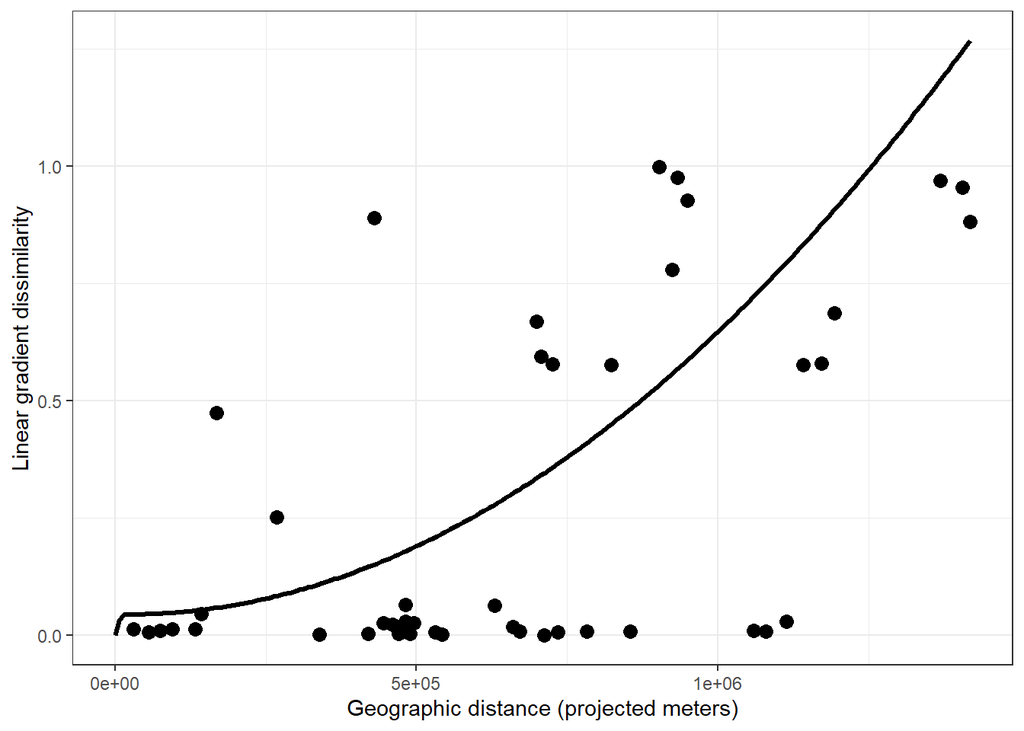

```r
# Plots
gdm.1.splineDat <- isplineExtract(gdmTabMod_lin)
df_spline_geo <- data.frame(x = gdm.1.splineDat$x[, "matrix_1"],
                        y = gdm.1.splineDat$y[, "matrix_1"])
df_points_geo <- gdmTab2 %>%
  mutate(
    geo_dist = sqrt((s1.xCoord - s2.xCoord)^2 + (s1.yCoord - s2.yCoord)^2)
  )

ggplot() +
  geom_point(
    data = df_points_geo,
    aes(x = geo_dist, y = distance),
    size = 3
  ) +
  geom_line(
    data = df_spline_geo,
    aes(x = x, y = y),
    linewidth = 1.2
  ) +
  labs(
    x = "Geographic distance (projected meters)",
    y = "Linear gradient dissimilarity") +
  theme_bw()
```

```r
# Create initial site-pair table for nonlinear gradients (bioFormat = 3)
gdmTab3 <- formatsitepair(
  bioData = nonlin_grad,     # biological distance matrix + site column
  bioFormat = 3,
  XColumn = "Long",
  YColumn = "Lat",
  siteColumn = "site",
  predData  = predData_proj      # coordinates table
)

# bioFormat = 4
## adds a predictor matrix to an existing site-pair table, in this case,
## predData needs to be provided, but is not actually used

# Geographic distance matrix
# geo_dist <- as.matrix(data.frame(site = 1:nrow(coords),
#                                 as.matrix(dist(coords))))

# build the GDM site-pair table
gdmTab4 <- formatsitepair(
  bioData = gdmTab3,     # dissimilarity matrix with 'site' column
  bioFormat = 4,            # dissimilarity matrix
  siteColumn = "site",
  predData  = predData_proj,    # REQUIRED for format 4
  distPreds = distPreds_list
)
```

## 9.3 Nonlinear selection: GDM fit and plotting

```r
##### Fit GDM
gdmTabMod_nonlin <- gdm(gdmTab4, geo = F)

# Percent Deviance Explained: goodness-of-fit
# Intercept: expected dissimilarity between sites that do not differ in the predictors
# Summary of the fitted I-splines for each predictor, including the values of the
# coefficients and their sum.
# The sum indicates the amount of compositional turnover associated with that variable,
# holding all other variables constant. I-spline summaries are ordered by coefficient sum.
# Variables with all coefficients=0 have no relationship with the modeled biological pattern.
summary(gdmTabMod_nonlin)
```

```
## [1]
## [1]
## [1] GDM Modelling Summary
## [1] Creation Date:  Wed Apr  1 15:30:05 2026
## [1]
## [1] Name:  gdmTabMod_nonlin
## [1]
## [1] Data:  gdmTab4
## [1]
## [1] Samples:  45
## [1]
## [1] Geographical distance used in model fitting?  FALSE
## [1]
## [1] NULL Deviance:  31.847
## [1] GDM Deviance:  24.001
```

[output cut: 55 more lines]

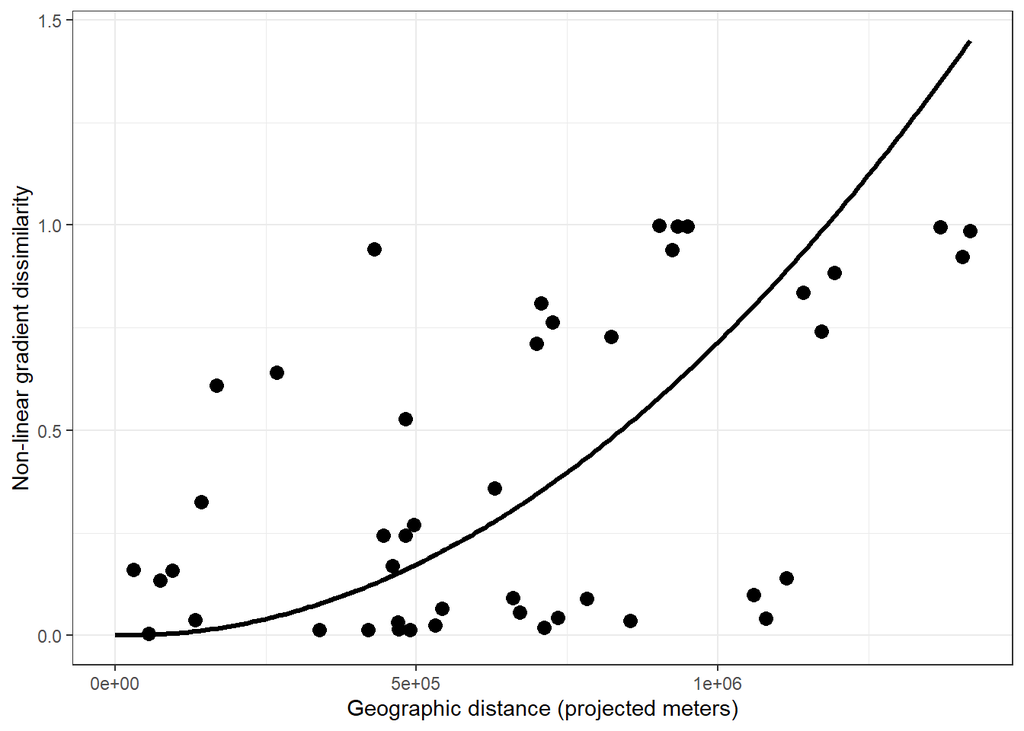

```r
# Plots (5x4 in)
gdm.2.splineDat <- isplineExtract(gdmTabMod_nonlin)
df_spline_m1 <- data.frame(
  x = gdm.2.splineDat$x[, "matrix_1"],
  y = gdm.2.splineDat$y[, "matrix_1"]
)

df_points_m1 <- gdmTab4 %>%
  mutate(
    beta_comp = abs(s1.matrix_1 - s2.matrix_1)
  )

ggplot() +
  geom_point(
    data = df_points_m1,
    aes(x = beta_comp, y = distance),
    size = 3
  ) +
  geom_line(
    data = df_spline_m1,
    aes(x = x, y = y),
    linewidth = 1.2
  ) +
  labs(
    x = "Geographic distance (projected meters)",
    y = "Non-linear gradient dissimilarity"
  ) +
  theme_bw()
```

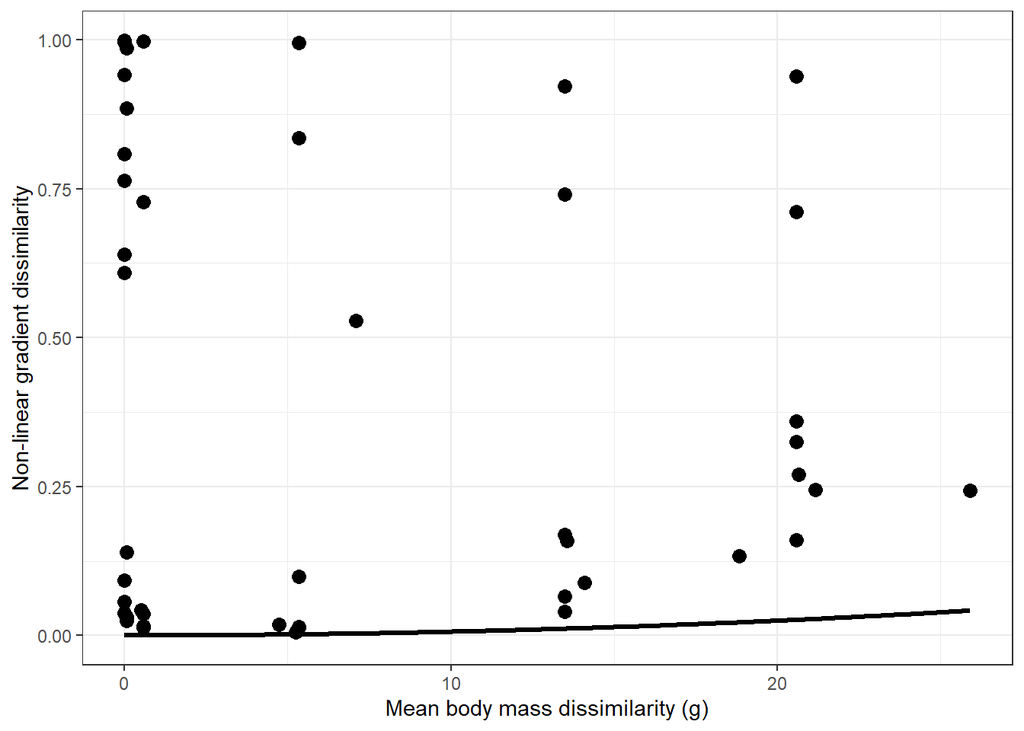

```r
gdm.2.splineDat <- isplineExtract(gdmTabMod_nonlin)
df_spline_m1 <- data.frame(
  x = gdm.2.splineDat$x[, "matrix_4"],
  y = gdm.2.splineDat$y[, "matrix_4"]
)

df_points_m1 <- gdmTab4 %>%
  mutate(
    beta_comp = abs(s1.matrix_4 - s2.matrix_4)
  )

ggplot() +
  geom_point(
    data = df_points_m1,
    aes(x = beta_comp, y = distance),
    size = 3
  ) +
  geom_line(
    data = df_spline_m1,
    aes(x = x, y = y),
    linewidth = 1.2
  ) +
  labs(
    x = "Mean body mass dissimilarity (g)",
    y = "Non-linear gradient dissimilarity"
  ) +
  theme_bw()
```